# Iowa Nutrient Research Center Progress Report

January 22, 2019

Table 1: Rain and surface runoff cumulative totals (inches) for 2018

| Site | Rain | Runoff Control | Runoff Treatment |
| --- | --- | --- | --- |
| Armstrong | 26.50 | 0.14 | 0.05 |
| E. IA Airport | 31.26 | 3.10 | 1.79 |
| Marshalltown | 14.21 | 0.04 | 0.46 |
| McNay | 16.89 | 0.56 | 4.87 |
| Rhodes | 31.54 | 4.60 | 1.76 |
| Spirit Lake | 11.85 | 0.58 | 0.55 |
| Whiterock | 23.86 | 2.54 | 1.62 |
| Worle | 28.58 | 3.41 | 2.49 |

Nutrient loss summaries (Table 2) show variable results between the treatment and control fields. These will require further and deeper investigation to better understand, and will most likely require analysis on a single runoff event scale, not the entire monitoring season.

Groundwater depth monitoring is presented in Figure 5. Groundwater tends to be closer to the surface in the fields without prairie strips. Groundwater nutrient analyses results have yet to be returned to us from the lab, but will be reported as soon as possible.

| Site | Rain (in.) | Runoff (in.) Control | Runoff (in.) Treatment |
| --- | --- | --- | --- |
| Armstrong | 26.50 | 0.14 | 0.05 |
| E. IA Airport | 31.26 | 3.10 | 1.79 |
| Marshalltown | 14.21 | 0.04 | 0.46 |
| McNay | 16.89 | 0.56 | 4.87 |
| Rhodes | 31.54 | 4.60 | 1.76 |
| Spirit Lake | 11.85 | 0.58 | 0.55 |
| Whiterock | 23.86 | 2.54 | 1.62 |
| Worle | 28.58 | 3.41 | 2.49 |

Table 2: 2018 Nutrient loss end-of-year totals for each monitored site. Fields without prairie strips are the “Control”, while fields with prairie strips are the “Treatment”. There are inconsistent results based on the entire season’s totals. Further investigation is needed at the single runoff event scale.

| Site | Nitrate (lbs/ac) Control | Nitrate (lbs/ac) Treatment | Orthophosphate (lbs/ac) Control | Orthophosphate (lbs/ac) Treatment | Total Suspended Solids (lbs/ac) Control | Total Suspended Solids (lbs/ac) Treatment |
| --- | --- | --- | --- | --- | --- | --- |
| Armstrong | 0.00 | 0.00 | 0.00 | 0.00 | 0.43 | 0.00 |
| E. IA Airport | 0.36 | 0.06 | 0.05 | 0.03 | 22.77 | 69.47 |
| Marshalltown | 0.00 | 0.00 | 0.00 | 0.00 | 0.06 | 0.00 |
| McNay | 0.02 | 0.26 | 0.03 | 0.13 | 8.99 | 107.81 |
| Rhodes | 0.17 | 0.64 | 0.24 | 0.07 | 106.95 | 33.88 |
| Spirit Lake | 0.52 | 0.08 | 0.00 | 0.00 | 42.54 | 9.80 |
| Whiterock | 0.00 | 0.19 | 0.02 | 0.03 | 113.54 | 48.04 |
| Worle | 0.17 | 0.16 | 0.06 | 0.05 | 74.70 | 110.40 |

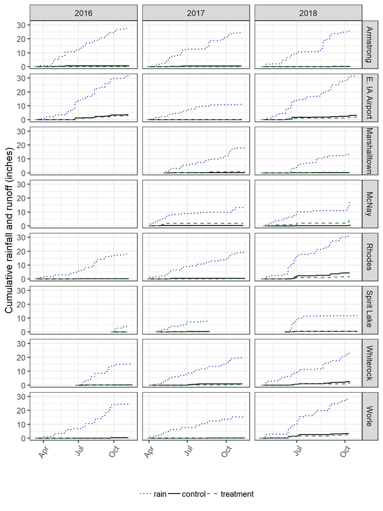

Figure 1: Rain and surface runoff summaries in inches from 2016-2018. Fields without prairie strips are the “control”, while fields with prairie strips are the “treatment”. There was a greater number of runoff events in 2018 than the previous two years.

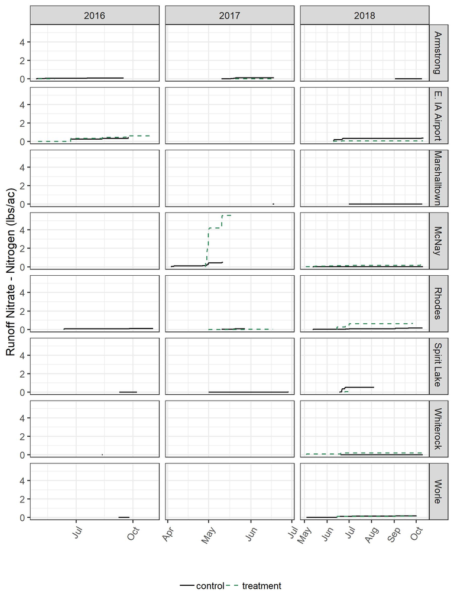

Figure 2: Nitrate export estimates via surface runoff in pounds per acre. Fields without prairie strips are the “control”, while fields with prairie strips are the “treatment”. Between-treatment results vary among sites.

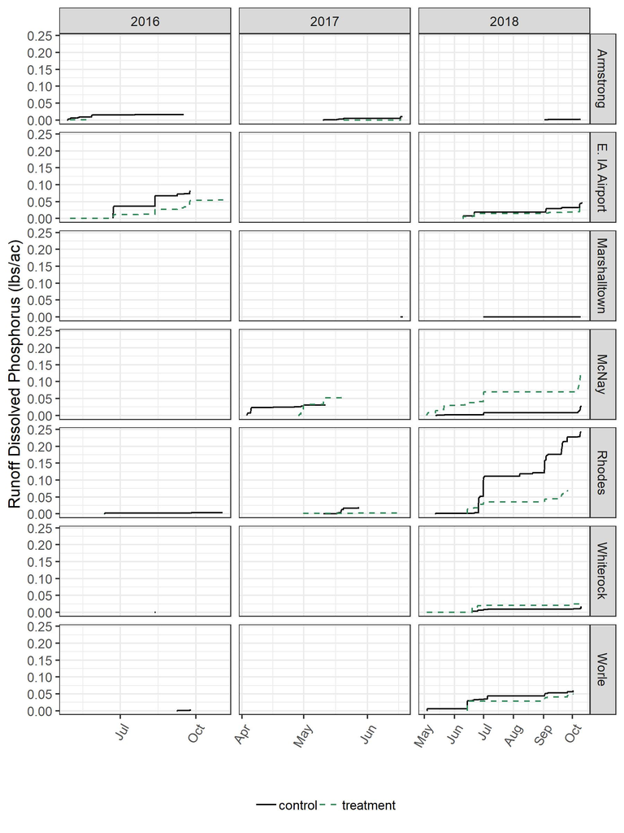

Figure 3: Orthophosphate export estimates via surface runoff in pounds per acre. Fields without prairie strips are the “control”, while fields with prairie strips are the “treatment”. Between-treatment results vary among sites.

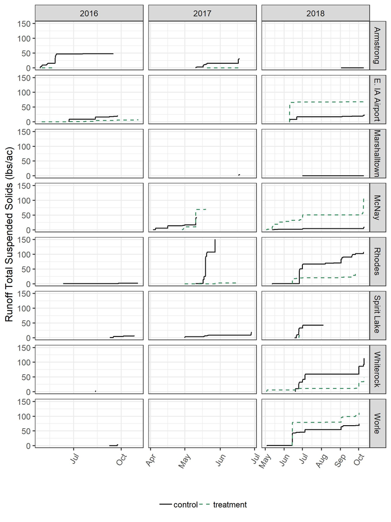

Figure 4: Total suspended solids export estimates via surface runoff in pounds per acre. Fields without prairie strips are the “control”, while fields with prairie strips are the “treatment”. Between-treatment results vary among sites.

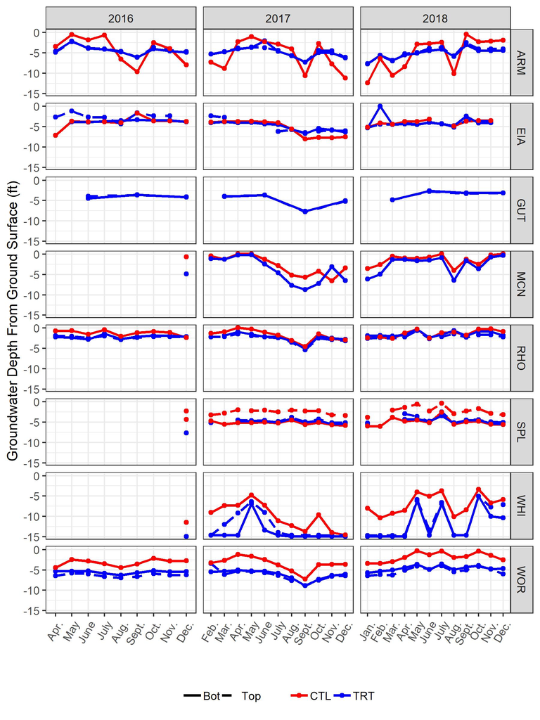

Figure 5: Monthly groundwater depth measurements in feet from surface of ground. Groundwater tends to be nearer to the surface in fields without prairie strips (CTL) than when prairie strips are present (TRT).